# Project_Applied_Statistics_Puneet

The label encoder can be used to transform categorical values to numeric encoding as given in  
https://pbpython.com/categorical-encoding.html (other techniques than the one illustrated below are also provided) Using the same as given below

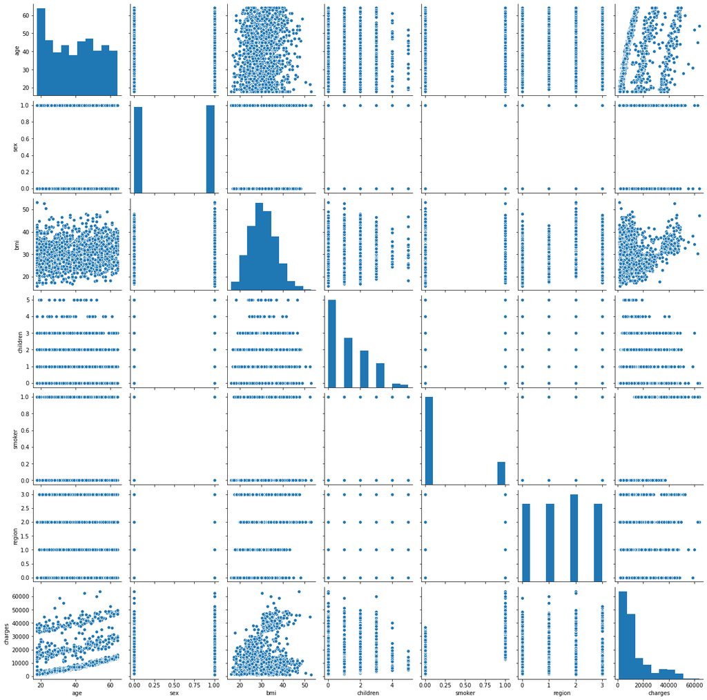

```python
lb_make = LabelEncoder()
# make a copy of the df so that the original dataset is not impacted
ins_data_copy = copy.deepcopy(ins_data)
ins_data_copy.loc[:,['smoker', 'region', 'sex']] = ins_data.loc[:,['smoker', 'region', 'sex']].apply(lb_make.fit_transform)
sns.pairplot(ins_data_copy);
```

**Q 4a Do charges of people who smoke differ significantly from the people who don't.**

With hypothesis testing using the t test we can find whether there is a relationship between smoking and non smoking charges.  
Null Hypothesis is The charges are same for smoker and non smoker  
Alternate Hypothesis is That the charges are either greater or less but not equal (not same).

```python
ins_data.head()
```

|  | age | sex | bmi | children | smoker | region | charges |
| --- | --- | --- | --- | --- | --- | --- | --- |
| 0 | 19 | female | 27.900 | 0 | yes | southwest | 16884.92400 |
| 1 | 18 | male | 33.770 | 1 | no | southeast | 1725.55230 |
| 2 | 28 | male | 33.000 | 3 | no | southeast | 4449.46200 |
| 3 | 33 | male | 22.705 | 0 | no | northwest | 21984.47061 |
| 4 | 32 | male | 28.880 | 0 | no | northwest | 3866.85520 |

```python
smokers = np.array(ins_data[ins_data["smoker"]=="yes"].charges)
non_smokers = np.array(ins_data[ins_data["smoker"]=="no"].charges)
t_statistic, p_value = ttest_ind(smokers,non_smokers)
print(t_statistic,p_value)
```

```
46.664921172723716 8.271435842177219e-283
```

The p value is much less than .025. Using .025 as the charges can differ in either direction. **The null hypothesis has to be rejected.** The non smokers pay much less charges than the smokers

**Q4.b. Does bmi of males differ significantly from that of females?**  
Again using the same approach as above we formulate the null and alternative hypothesis and doing a t test to conclude whether to accept or reject null hypothesis  
Null Hypothesis - bmi remains same for males and females  
Alternate Hypothesis - bmi is different for males and females(either greater or less)

```python
female = np.array(ins_data[ins_data["sex"]=="female"].bmi)
male = np.array(ins_data[ins_data["sex"]=="male"].bmi)
t_statistic, p_value = ttest_ind(female,male)
print(t_statistic,p_value)
```

```
-1.696752635752224 0.08997637178984932
```

The p value is higher than .05. **Hence we cannot reject the Null Hypothesis.**

**Q 4.c. Is the proportion of smokers significantly different in different genders?** We can use the z test of proportions to determine whether the smokers for different genders have different proportions  
Null Hypothesis : The proportions are same Alternate Hypothesis : The proportions are different

```python
female_smokers = ins_data[ins_data["sex"]=='female'].smoker.value_counts()[1]
male_smokers = ins_data[ins_data["sex"]=='male'].smoker.value_counts()[1]
males = ins_data.sex.value_counts()[0]
females = ins_data.sex.value_counts()[1]
print([female_smokers, male_smokers] , [females, males])
print(f' Proportion of smokers in females, males = {round(115/662,2)}%, {round(159/676,2)}% respectively')
```

```
[115, 159] [662, 676]
 Proportion of smokers in females, males = 0.17%, 0.24% respectively
```

The proportions seem to be different but we have to check if they are statistically significant

```python
t_stats, p_val = proportions_ztest([female_smokers,male_smokers],[females,males])
print(t_stats,p_val)
```

```
-2.7867402154855503 0.005324114164320532
```

As the p value is much less than the value of .05 we can **reject the null hypothesis**

**Q 4.d.** Is the distribution of bmi across women with no children, one child and two children, the same?  
The problem falls into the category of comparing multiple groups and therefore a candidate for Oneway Anova.  
Null Hypothesis : "the distribution of bmi across women with no children, one child and two children are same"  
Alternate Hypothesis: "the distribution of bmi across women with no children, one child and two children are different"

```python
ins_data.head()
```

|  | age | sex | bmi | children | smoker | region | charges |
| --- | --- | --- | --- | --- | --- | --- | --- |
| 0 | 19 | female | 27.900 | 0 | yes | southwest | 16884.92400 |
| 1 | 18 | male | 33.770 | 1 | no | southeast | 1725.55230 |
| 2 | 28 | male | 33.000 | 3 | no | southeast | 4449.46200 |
| 3 | 33 | male | 22.705 | 0 | no | northwest | 21984.47061 |
| 4 | 32 | male | 28.880 | 0 | no | northwest | 3866.85520 |

```python
# get the data for female for various categories
ins_data.head()
female_data = ins_data[ins_data['sex'] == 'female']
female_no_child = female_data[female_data.children == 0].bmi
female_one_child = female_data[female_data.children == 1].bmi
female_two_child = female_data[female_data.children == 2].bmi
ins_data.head()

stats.levene(female_no_child, female_one_child, female_two_child)
```

```
LeveneResult(statistic=0.9433311607108589, pvalue=0.3899432394522804)
```

```python
stats.shapiro(female_no_child), stats.shapiro(female_one_child), stats.shapiro(female_two_child)
```

```
(ShapiroResult(statistic=0.9896312355995178, pvalue=0.03757598251104355),
 ShapiroResult(statistic=0.9921025037765503, pvalue=0.5361911654472351),
 ShapiroResult(statistic=0.9860439300537109, pvalue=0.2596229910850525))
```

```python
F, p = stats.f_oneway(female_no_child,female_one_child,female_two_child)
print(F,p)
```

```
0.3344720147757968 0.7158579926754841
```

The p value is greater than the alpha value and hence we **fail to reject** the null hypothesis that the distribution of bmi across women with no children, one child and two children are not different or there is no effect of number of children on the bmi in females.